# Choosing the right method for measuring acoustic signal structure

2017-02-17

Bioacoustic research relies on quantifying the structure of acoustic signals and comparing that structure across behavioral/ecological contexts, groups or species. However, measuring signal structure in a way that fully accounts for the variation in the signals could be a tricky task. Some of the differences that are apparent by visual inspection of spectrograms might not be picked up by some analyses. Hence, choosing the most appropriate analytical approach is a critical step.

The warbleR function `compare.methods` attempts to facilitate method selection. This function produces graphs (as image files in the working directory) with spectrograms from 4 signals that allow visual inspection of the performance of acoustic analysis methods at comparing those signals. The signals are randomly picked up from the provided data frame (X argument). The function compares 2 methods at a time. The methods available are: cross-correlation (using the warbleR function `xcorr`), dynamic time warping on dominant frequency time series (using `dfDTW`), dynamic time warping on fundamental frequency time series (using `ffDTW`), and spectral parameters (using `specan`). The graphs also contain 2 scatterplots (1 for each method) of the acoustic space of all signals in the input data frame ‘X’. The position of the 4 signals in the spectrograms is highlighted in the acoustic space scatterplot. In this way users can directly assess if the distances between signals in the acoustic space accurately represents the spectrographic similarity (e.g. how similar their acoustic structure looks in the spectrograms).

This is a short example on how to use the function using the data files included in the package. You need warbleR version 1.1.5 or higher to be able to run the code.

First load the package and save the example sound files in the working directory

```r
library(warbleR)

data(list = c("Phae.long1", "Phae.long2", "Phae.long3", "Phae.long4", "selec.table"))
writeWave(Phae.long1,"Phae.long1.wav")
writeWave(Phae.long2,"Phae.long2.wav")
writeWave(Phae.long3,"Phae.long3.wav")
writeWave(Phae.long4,"Phae.long4.wav")
```

Then just run the function selecting the 2 methods that you want to compare. The code below compares cross-correlation (`XCORR`) and dynamic time warping on dominant frequency contours (`dfDTW`). The compared selections are randomly picked up from the pool of selections in the input data frame. The argument ‘n’ defines the number of comparisons (i.e. graphs) to be carried out.

```r
compare.methods(X = selec.table, flim = c(0, 10), bp = c(0, 10),
                wl = 300, n = 10, methods = c("XCORR", "dfDTW"))
```

It should produce 10 image files (in the working directory) that look like these ones:

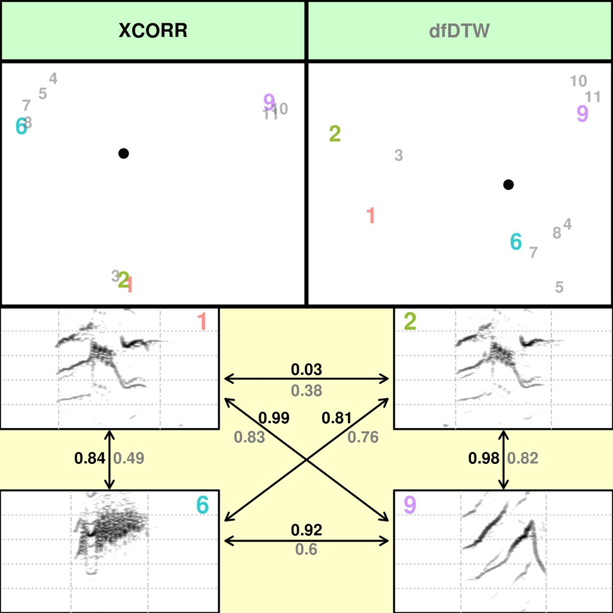

compare.methods_example1

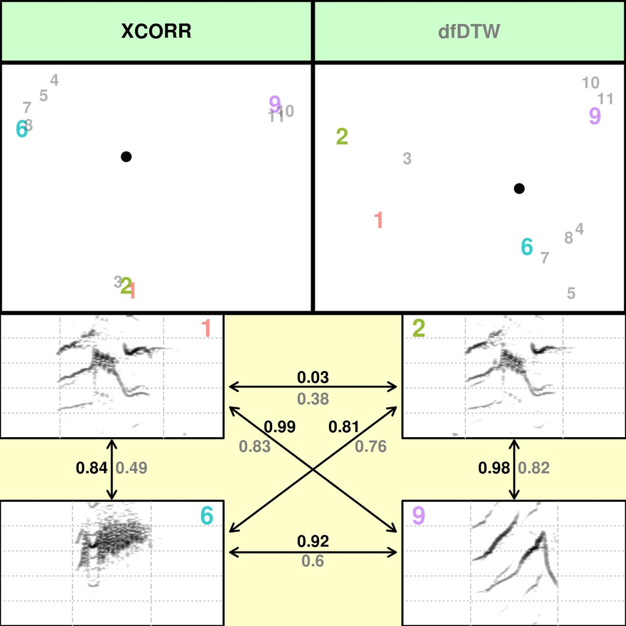

compare.methods_example1

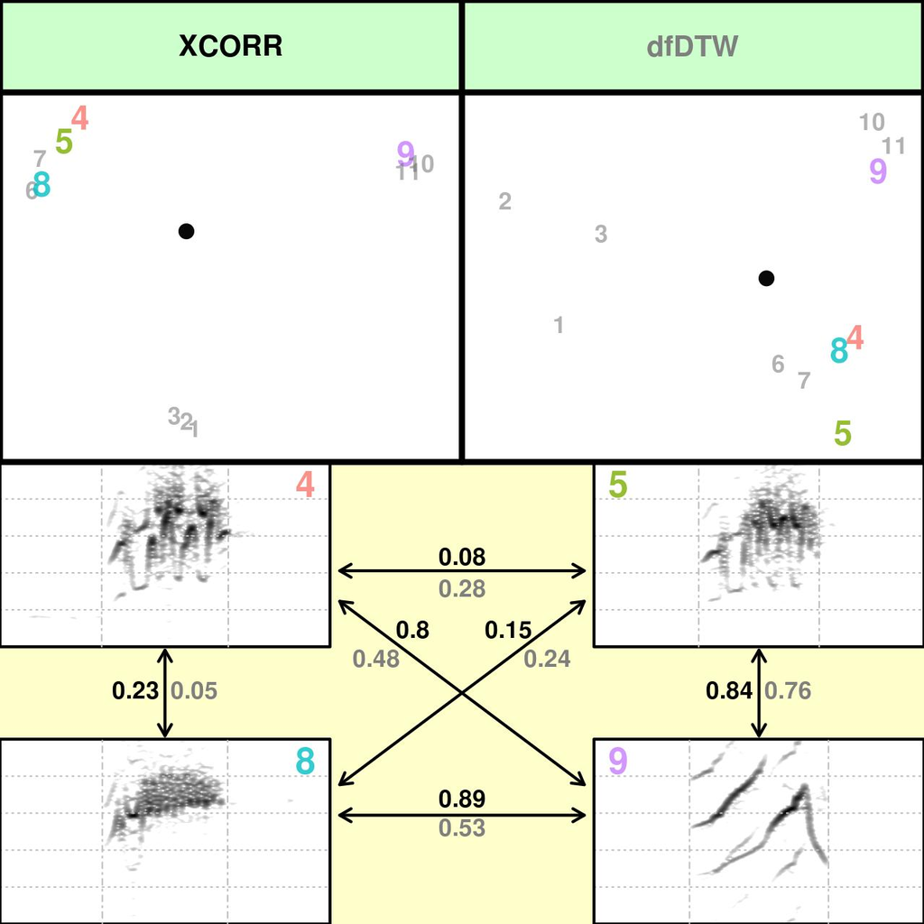

compare.methods_example2

(You can tell where you working directory is found by running getwd())

The acoustic pairwise distance between signals is shown next to the arrows linking them. The font color of a distance value corresponds to the font color of the method that generated it, as shown in the scatterplots (in this case black font represents XCORR distances). Distances are standardize, being 0 the distance of a signal to itself and 1 the farthest pairwise distance in the pool of signals. Principal Component Analysis (`princomp` function) is applied to calculate distances when using spectral parameters (SP). In that case the first 2 PC’s are used. Classical Multidimensional Scaling (also known as Principal Coordinates Analysis, `cmdscale` function) is used for all other methods. The file name contains the methods being compared and the row number of the selections. This function uses internally a modified version of the `spectro` function from
$$seewave$$
((https://cran.r-project.org/package=seewave) package to create spectrograms. Note that the spectrograms are all plotted with the same frequency and time scales.

To include the SP method (spectral parameters) using this data we need to create a larger data set as the PCA that summarizes the spectral parameters needs more units (rows) that variables (columns). So just create a new selection table repeating 3 times selec.table. It’s a silly example but it’s just to show how it works, you don’t need to do this if you have more signals than the number of spectral parameters in `specan` (which at this time is 25)

```r
st2 <- rbind(selec.table, selec.table, selec.table)

#note that the selection labels should be also changed
st2$selec <- 1:nrow(st2)

#now we can compare SP method against XCORR
compare.methods(X = st2, flim = c(0, 10), bp = c(0, 10),
                wl = 300, n = 10, methods = c("XCORR", "SP"))
```

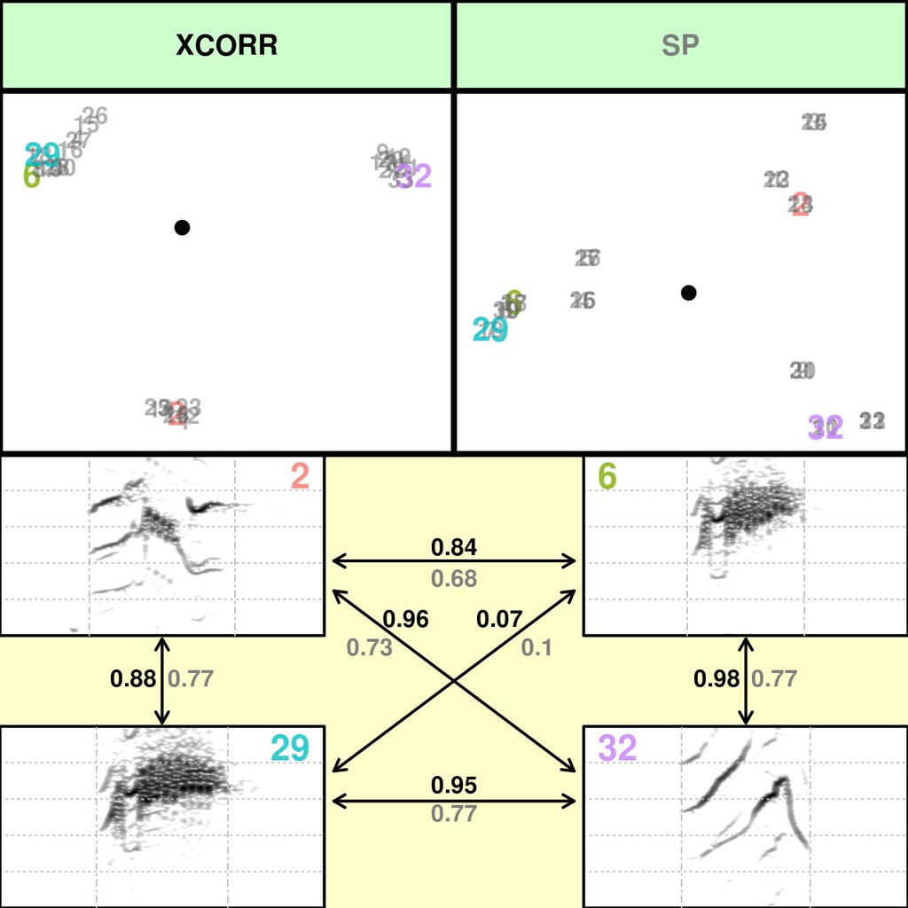

compare.methods_example2

Alternatively, you can provide you own data. This could be helpful for removing undesired parameters or to input parameters obtained elsewhere (e.g from Raven). To do so, input your data with the `sp` argument. “SP” must be included as a method in the ‘methods’ argument. The example below 1) calculates the spectral parameters with the `specan` function, 2) selects only the first 7 columns of the output, and 3) inputs this data into `compare.methods`.

```r
sp <- specan(selec.table, bp = c(0, 10))

sp <- sp[, 1:7]

compare.methods(X = selec.table, flim = c(0, 10), sp = sp, bp = c(0, 10),
                wl = 300, n = 10, methods = c("dfDTW", "SP"))
```

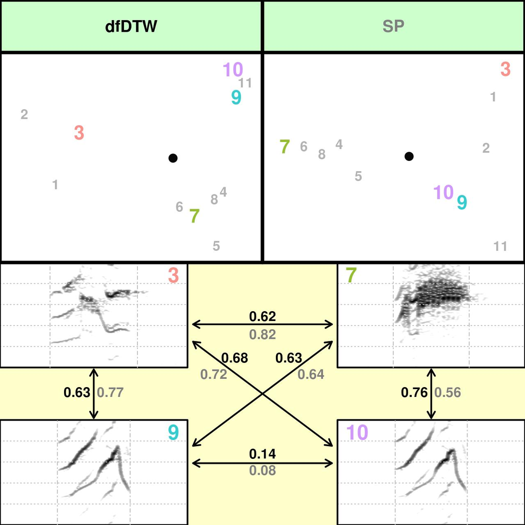

compare.methods_example2

The function has many other arguments to specify methods (e.g. bandpass, overlap) and spectrogram settings (e.g. margin, grid, frequency limits). Take a look at the function help document.